# README for consmap-prep

Ben Best

October 6, 2015

# Overview

Once you have species distributions, how do you use them to make decisions? We’re encouraged through multiple avenues (Presidential Order, Pew Report…) to move away from single species management to a holistic ecosystem-based management. So we want to combine the species distributions, but how?

Borrowing from [Maxwell et al (2013)](http://www.nature.com.proxy.lib.duke.edu/ncomms/2013/131028/ncomms3688/full/ncomms3688.html), we can apply species-specific impact weight. For instance, more acoustically sensitive species have a stronger weight based on offshore pile driving as a human activity.

TODO: explore weighting, sensitivity analysis:

- industry weights
- literature explore weighting:
- multi-criteria decision analysis
- IUCN / NatureServe advice on weighting
- [Selig et al (2013)](http://journals.plos.org/plosone/article?id=10.1371/journal.pone.0060284)
- diagram of inputs / process

Questions: 1. Rather than divide by guild, should I divide by species, ie multiply guilds by # of species?

# Industry

- wind intensity
- distance to shore
- depth
- slope
- distance to shore / transmission. with/without Atlantic Wind Connection

[interactive chart not shown]

# Species

## Species Weights

The species weights (**w**) are based on the NatureServe global extinction status which have a reasonable value for all species, unlike IUCN for which many are data deficient (DD).

|  | sp_name | sp_code | sp_scientific | group | ec | natureserve | iucn_status | iucn_status_subcode | iucn_notes | esa_listed | w |
| --- | --- | --- | --- | --- | --- | --- | --- | --- | --- | --- | --- |
| 1 | Atlantic spotted dolphin | Atlantic_spotted_dolphin | Stenella frontalis | Small delphinoids | True | G5 | DD |  |  |  | 1 |
| 2 | Atlantic white-sided dolphin | Atlantic_white_sided_dolphin | Lagenorhynchus acutus | Small delphinoids | True | G4 | LC |  |  |  | 25.75 |
| 3 | Beaked whales | Beaked_whales | Mesoplodon bidens | Beaked and sperm whales | True | G3 | DD |  |  |  | 50.5 |
| 4 | Beaked whales | Beaked_whales | Mesoplodon densirostris | Beaked and sperm whales | True | G4 | DD |  |  |  | 25.75 |
| 5 | Beaked whales | Beaked_whales | Mesoplodon europaeus | Beaked and sperm whales | True | G3 | DD |  |  |  | 50.5 |
| 6 | Beaked whales | Beaked_whales | Mesoplodon mirus | Beaked and sperm whales | True | G3 | DD |  |  |  | 50.5 |
| 7 | Beaked whales | Beaked_whales | Ziphius cavirostris | Beaked and sperm whales | True | G4 | LC |  |  |  | 25.75 |
| 8 | Blue whale | Blue_whale | Balaenoptera musculus | Baleen whales | True | G3G4 | VU | D1 | North Atlantic stock |  | 38.125 |
| 9 | Bottlenose dolphin | Bottlenose_dolphin | Tursiops truncatus | Small delphinoids | True | G5 | LC |  |  |  | 1 |
| 10 | Brydes whale | Brydes_whale | Balaenoptera edeni | Baleen whales | True | G4 | DD |  |  |  | 25.75 |

[output cut: 25 more lines]

|  | sp_code | w |
| --- | --- | --- |
| 1 | North_Atlantic_right_whale | 100 |
| 2 | Sei_whale | 50.5 |
| 3 | Beaked_whales | 40.6 |
| 4 | Blue_whale | 38.125 |
| 5 | Fin_whale | 38.125 |
| 6 | Sperm_whale | 38.125 |
| 7 | Atlantic_white_sided_dolphin | 25.75 |
| 8 | Brydes_whale | 25.75 |
| 9 | Clymene_dolphin | 25.75 |
| 10 | False_killer_whale | 25.75 |

[output cut: 19 more lines]

## EC

[interactive chart not shown]

## EC, Over Time

[interactive chart not shown]

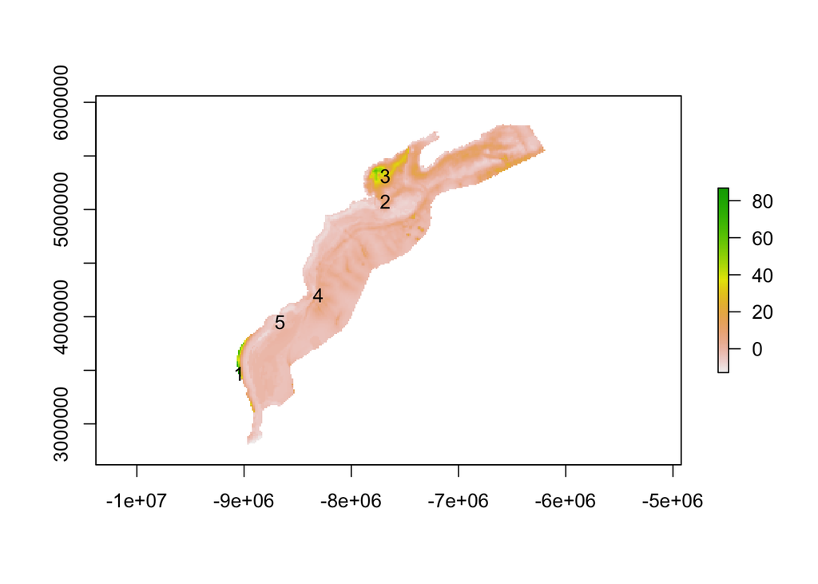

[interactive chart not shown]

TODO: zoom into pixel and break down across time by species.

## GOM

[interactive chart not shown]